# Stop Building Dashboards

- Show All Code
- Hide All Code

*Start Understanding the White Collar Workflow*

python

sql

Author

Jesus L. Monroy

Published

Feb, 2025

Abstract

In today’s data-driven world, Business Intelligence (BI) tools promise powerful insights and streamlined reporting. Yet, the humble spreadsheet and slideshow persist in the white-collar world. While BI tools manages complex analysis and visualization, spreadsheets and slideshows offer unique advantages that keep them firmly entrenched in our workflows.

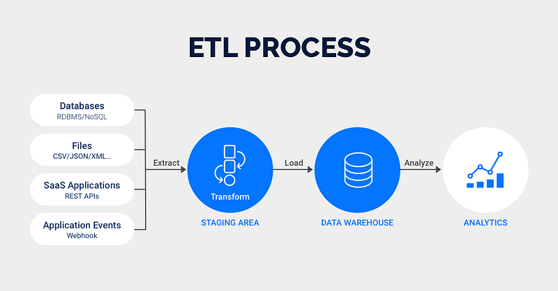

Figure 1: ETL Phases

## Overview

Some reasons why spreadsheets and slideshows persist in the office workflow, include:

- Familiarity and Ease of Use
- Flexibility and Control
- Storytelling and Communication
- Collaboration and Sharing
- Ad-hoc Analysis and Exploration
- Cost and Accessibility

While BI tools may be transforming the way we analyze data, it’s clear that spreadsheets and slideshows aren’t going anywhere anytime soon. They serve a different purpose, filling a gap that BI tools often miss.

Building a Python-Powered Data Pipeline

Business Intelligence (BI) tools are powerful, but they can also be expensive and complex. What if you could build a custom, flexible, and potentially more cost-effective solution using Python?

This post explores how you can leverage Python to collect, transform, and deliver data to Spreadsheets and Slides for compelling presentations. Why Python?

Python has become a powerhouse in data science and automation. Its rich ecosystem of libraries makes it ideal for data manipulation, and seamless slides interaction. This combination offers a powerful alternative to traditional BI tools for certain use cases.

In this post we shall propose the use of Python (to collect, cleanse and transform data), Google Spreadsheets (to store transformed data) and Google Slides (to showcase visualizations). Proposed Workflow

Imagine you need to generate a weekly sales report and all you have to do is to run the next command:

```python
%%bash
jupyter-execute ./projects/weekly-report.ipynb
```

And, voila! you have your weekly report updated and ready to present in Google Slides.

## Environment settings

```python
# Import authenticator and gspread to manage g-sheets
from oauth2client.service_account import ServiceAccountCredentials
import gspread

# Import other libraries
import numpy as np
import pandas as pd
import polars as pl
import duckdb as db
import json
import warnings
warnings.filterwarnings('ignore')
```

```python
# get token
filename = 'credentials.json'

# read json file
with open(filename) as f:
    keys = json.load(f)

# read credentials
token = keys['md_token']
```

## Extract Phase

```python
# connect to motherduck cloud
conn = db.connect(f'md:?motherduck_token={token}')
```

```python
conn.sql('show databases')
```

```
┌───────────────────────┐
│     database_name     │
│        varchar        │
├───────────────────────┤
│ md_information_schema │
│ my_db                 │
│ my_portfolio          │
│ sample_data           │
└───────────────────────┘
```

Table 1: Databases

```python
# select specific database
conn.sql('use my_portfolio')
```

```python
# show tables in database
conn.sql('show tables')
```

```
┌──────────────────┐
│       name       │
│     varchar      │
├──────────────────┤
│ airports         │
│ appl_stock       │
│ cdmx_subway      │
│ colors           │
│ contains_null    │
│ houses           │
│ people           │
│ prevalencia      │
│ restaurants      │
│ retail_sales     │
│ sales            │
│ sales_info       │
│ sets             │
│ water_collection │
├──────────────────┤
│     14 rows      │
└──────────────────┘
```

Table 2: Tables in database

```python
# dataset
dataset = conn.sql('select * from restaurants').df()

(
    dataset.head()
        .style
        .hide()
        .format({'rating_count': '{:,.0f}', 'cost': '${:.2f}'})
)
```

| name | rating_count | cost | city | cuisine | rating |
| --- | --- | --- | --- | --- | --- |
| The Golden Wok | 1,477 | $33.62 | Berlin | American | 5 |
| Greek Gyros | 770 | $68.39 | New York | French | 1 |
| Taste of Italy | 4,420 | $88.23 | Amsterdam | Chinese | 0 |
| Midnight Diner | 2,155 | $12.97 | Lisbon | Mexican | 1 |
| Taste of Italy | 3,375 | $52.79 | Sydney | Chinese | 1 |

Table 3: Dataset Preview

## Transform Phase

### Which restaurant chain has the maximum number of restaurants?

```python
chains = (
    conn.sql('''
    select name, count(name) as no_of_chains
    from restaurants
    group by name
    order by no_of_chains DESC
    limit 10
    ''').df()
)
chains
```

|  | name | no_of_chains |
| --- | --- | --- |
| 0 | The Burger Joint | 721 |
| 1 | Pizza Palace | 703 |
| 2 | Greek Gyros | 696 |
| 3 | Cafe Delight | 692 |
| 4 | French Delights | 681 |
| 5 | The BBQ Shack | 671 |
| 6 | The Golden Wok | 667 |
| 7 | Ocean Breeze | 665 |
| 8 | Spice & Bloom | 665 |
| 9 | Midnight Diner | 657 |

Table 4: Data grouped by restaurant chains

### Which restaurant chain has generated maximum revenue?

```python
revenue = (
    conn.sql('''
    select name, sum(rating_count * cost) as revenue
    from restaurants
    group by name
    order by revenue DESC
    limit 10
    ''').df()
)

(
    revenue
        .style
        .hide()
        .format({'revenue': '{:,.2f}'})
)
```

| name | revenue |
| --- | --- |
| The Burger Joint | 108,820,424.64 |
| Pizza Palace | 100,382,853.92 |
| Cafe Delight | 98,037,063.93 |
| Greek Gyros | 96,403,445.25 |
| The BBQ Shack | 96,286,414.02 |
| Ocean Breeze | 95,664,612.77 |
| The Golden Wok | 94,860,125.75 |
| Spice & Bloom | 91,824,854.56 |
| French Delights | 91,236,701.38 |
| Midnight Diner | 91,170,162.30 |

Table 5: Data grouped by restaurant and revenue

### Which city has generated maximum revenue?

```python
cities = (
    conn.sql('''
    select city, sum(rating_count * cost) as revenue
    from restaurants
    group by city
    order by revenue DESC
    limit 10
    ''').df()
)

(
    cities
        .style
        .hide()
        .format({'revenue': '${:,.2f}'})
)
```

| city | revenue |
| --- | --- |
| Amsterdam | $148,839,878.62 |
| Tokyo | $148,035,421.32 |
| Madrid | $141,487,618.97 |
| Paris | $141,219,374.56 |
| London | $140,876,613.54 |
| Rome | $139,622,129.63 |
| New York | $138,621,609.28 |
| Lisbon | $136,814,247.27 |
| Berlin | $136,434,163.25 |
| Sydney | $131,656,513.97 |

Table 6: Data grouped by city and revenue

## Load Phase

```python
# Create scope to authenticate
SCOPES = ['https://www.googleapis.com/auth/spreadsheets', 'https://www.googleapis.com/auth/drive']

# Read credentials
GOOGLE_SHEETS_KEY_FILE = 'arkham-538.json'
credentials = ServiceAccountCredentials.from_json_keyfile_name(GOOGLE_SHEETS_KEY_FILE, SCOPES)
gc = gspread.authorize(credentials)
```

```python
import pytz
import datetime

tz = pytz.timezone('America/Mexico_City')
update = datetime.datetime.now(tz).strftime('%b %d, %Y')
period = update
```

```python
def save_to_gsheets(df, sheet_name, worksheet_name, period):
    creds = ServiceAccountCredentials.from_json_keyfile_name(GOOGLE_SHEETS_KEY_FILE, SCOPES)
    client = gspread.authorize(creds)
    sheet = client.open(sheet_name)
    worksheet = sheet.worksheet(worksheet_name)

    # Convert datetimes to strings in advance
    for column in df.columns[df.dtypes == 'datetime64[ns]']:
        df[column] = df[column].astype(str)

    # Prepare data for batch update
    data = [df.columns.values.tolist()] + df.fillna('').values.tolist()

    # Freeze rows and update cell values with a single batch update
    worksheet.freeze(4)
    worksheet.update('A4:M', data)

    #fija fecha de consulta o actualizacion
    update_data = {
    'Last update': [
        period,]
    }

    # convert to dataframe
    update_data = pd.DataFrame(update_data, columns=['Last update'])

    worksheet.update([update_data.columns.values.tolist()] + update_data.fillna('').values.tolist(),'A1:A2',)

    print(f'DataFrame uploaded to: workbook: {sheet_name}, sheet: {worksheet_name}')
```

```python
save_to_gsheets(dataset, 'restaurants', 'data', period)
```

```
DataFrame uploaded to: workbook: restaurants, sheet: data
```

```python
save_to_gsheets(chains, 'restaurants', 'chains', period)
```

```
DataFrame uploaded to: workbook: restaurants, sheet: chains
```

```python
save_to_gsheets(revenue, 'restaurants', 'revenue', period)
```

```
DataFrame uploaded to: workbook: restaurants, sheet: revenue
```

```python
save_to_gsheets(cities, 'restaurants', 'cities', period)
```

```
DataFrame uploaded to: workbook: restaurants, sheet: cities
```

## Close connection

```python
# close connection
conn.close()
```

## Retrieve data from gsheets

```python
# Access worksheet id
df_id = '1JNAWb2QkFwh61v7QwEEVZnNhTPS0csbdMdll9y1csEg'
df_workbook = gc.open_by_key(df_id)
# Access data by worksheet sheet
df = df_workbook.worksheet('data')
# Save data to table
df = df.get_all_values()
# Save accessed data from google sheets to dataframe
df = pd.DataFrame(df[1:], columns=df[0])
```

```python
df.head()
```

|  | Last update |  |  |  |  |  |
| --- | --- | --- | --- | --- | --- | --- |
| 0 | Feb 24, 2025 |  |  |  |  |  |
| 1 |  |  |  |  |  |  |
| 2 | name | rating_count | cost | city | cuisine | rating |
| 3 | The Golden Wok | 1477 | 33.62048759 | Berlin | American | 5 |
| 4 | Greek Gyros | 770 | 68.38887409 | New York | French | 1 |

Table 7: Data Saved on Gogle Sheets

## Google Sheets Report Data

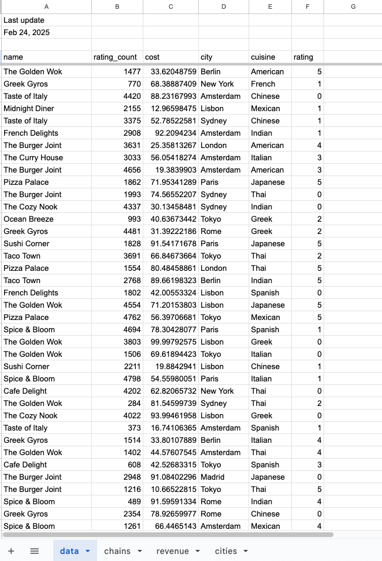

Figure 2: Google Sheets Data for Presentation Report

## Sync between Google Sheets and Google Slides

Simply we copy and paste with sync for each table and chart and customize our slides.

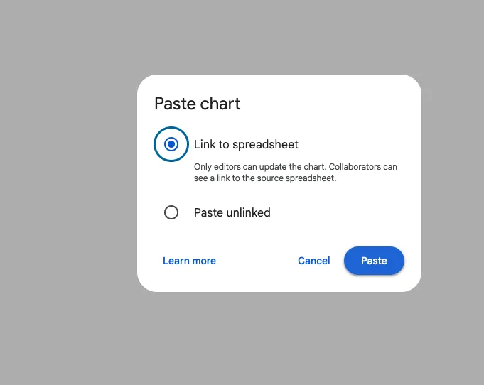

Figure 3: Synchronization between Google Sheets and Slides

**Google Slides**

You can see the final report on [Google Slides](https://docs.google.com/presentation/d/e/2PACX-1vSNbr2SozdFPzYGjDmd7_b_BvFRpCinWuD7fbRWDJd9hByA0-jKCTDsh1pX4gRmQFPQOdqkTcPcIG21/pub?start=false&loop=false&delayms=3000#slide=id.p)

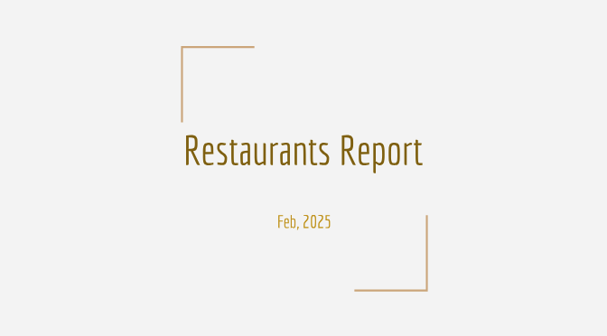

## Conclusions

This approach empowers you to take control of your data and create highly tailored reporting solutions by replacing BI license costs.

## References

- Business (2023) How to Design a Dashboard Presentation: A Step-by-Step Guide in slidemodel.com
- Karlson, P. (2022) Are Spreadsheets Secretly Running Your Business? in Forbes
- Monroy, Jesus (2024) Why BI Tools Fall Short: PowerPoint and Excel Still Rule the Business World in Medium
- Moore J. (2024) But, Can I Export it to Excel? in Do Mo(o)re with Data
- Schwab, P. (2021) Excel dominates the business world… and that’s not about to change in Into the Minds

## Contact

**Jesus L. Monroy**  
*Economist & Data Scientist*

[Medium](https://medium.com/@jesuslm) | [Linkedin](https://www.linkedin.com/in/j3sus-lm) | [Twitter](https://x.com/j3suslm)